# Lab 2: Data Manipulation

January 15, 2016

## Tonight:

- Pivots: wide-to-long and long-to-wide
  - `tidyr` and `reshape2`
- Full on data munging
  - `dplyr`
- Tidy model output and summary
  - `broom`

## Tools

R everything we do tonight can be done many different ways, in base R or using any number of packages.

Instead of focusing on that, I'm highlighting a small number of relatively new, well-maintained packages that have helped me get these jobs done easily and efficiently.

## Wide-to-long, long-to-wide

## `tidyr`

`tidyr` is the simplest tool for reshaping data - and the most limited. It does what you need 95% of the time, but sometimes you might need to bring in `resahpe2` for some extra features.

```r
reentry = read.csv("reentry.csv")
head(reentry[1:6])
```

```
##                      X   M3   M6   M9   M12   M15
## 1  All / Reunification 4.40 6.45 8.97 10.36 11.65
## 2       All / Adoption 0.49 1.10 1.47  1.59  1.71
## 3   All / Guardianship 1.19 2.37 4.15  4.45  5.34
## 4 King / Reunification 5.43 7.16 7.90  9.14 10.86
## 5      King / Adoption 0.74 0.74 1.12  1.12  1.12
## 6  King / Guardianship 1.79 4.46 6.25  7.14  8.04
```

Pretty nice data table for a person to read; **terrible** for working with.

```r
library(tidyr)
# gather many columns into two key/value columns
#    create a "key" column called months
#    create a "value" column called percent
#    do this for all *but* the first column
reentry = gather(reentry, key = months, value = percent, -1)
head(reentry)
```

```
##                      X months percent
## 1  All / Reunification     M3    4.40
## 2       All / Adoption     M3    0.49
## 3   All / Guardianship     M3    1.19
## 4 King / Reunification     M3    5.43
## 5      King / Adoption     M3    0.74
## 6  King / Guardianship     M3    1.79
```

## Going back to wide:

```r
spread(reentry, key = months, value = percent)[1:6, 1:6]
```

```
##                      X   M3   M6   M9   M12   M15
## 1       All / Adoption 0.49 1.10 1.47  1.59  1.71
## 2   All / Guardianship 1.19 2.37 4.15  4.45  5.34
## 3  All / Reunification 4.40 6.45 8.97 10.36 11.65
## 4      King / Adoption 0.74 0.74 1.12  1.12  1.12
## 5  King / Guardianship 1.79 4.46 6.25  7.14  8.04
## 6 King / Reunification 5.43 7.16 7.90  9.14 10.86
```

## Tidy Data Principles

- Data should be stored in columns, not in column names
- All values that measure the same thing should be in the same column

The ideas behind tidy data have been around for a long time, but this exact term was coined by Hadley Wickham, of course. He has a [Tidy Data Paper](http://www.jstatsoft.org/v59/i10) that is a good (quick) read - especially practical for those without much SQL/data warehousing experience.

Data that follows Tidy Data principles is easy to manipulate, easy to query, easy to plot (at least with ggplot), and easy to use in a model.

```r
fortunes::fortune("messy data")
```

```
##
## Happy families are all alike; every unhappy family is unhappy in its own
## way.
## Leo Tolstoy
##
## and every messy data is messy in its own way - it's easy to define the
## characteristics of a clean dataset (rows are observations, columns are
## variables, columns contain values of consistent types). If you start to
## look at real life data you'll see every way you can imagine data being
## messy (and many that you can't)!
##    -- Hadley Wickham (answering 'in what way messy data sets are messy')
##       R-help (January 2008)
```

## `reshape2`

`reshape2` can do the basic gather/spread that `tidyr` does, with some extra options. Instead of gather/spread, the commands are melt/cast.

```r
library(reshape2)
re2 = read.csv("reentry.csv")
re2 = melt(re2, id.vars = "X",
           variable.name = "months", value.name = "percent")
#     consistent Hadley syntax: function names use _ for word separation,
#     arguments use . for word separation
identical(reentry, re2)
```

```
## [1] TRUE
```

- `tidyr::gather` uses *non-standard evaluation*: i.e., unquoted column names
- `reshape2::melt` uses *standard evaluation*: column names must be strings (with quotes)
- `tidyr::gather` works on data frames only
- `reshap2::melt` works on data frames, lists, arrays, tables, matrices

## Other `tidyr` utilities

```r
reentry = separate(reentry, X, into = c("county", "outcome"))
head(reentry)
```

```
##   county       outcome months percent
## 1    All Reunification     M3    4.40
## 2    All      Adoption     M3    0.49
## 3    All  Guardianship     M3    1.19
## 4   King Reunification     M3    5.43
## 5   King      Adoption     M3    0.74
## 6   King  Guardianship     M3    1.79
```

- `unite` combines columns together (opposite of `separate`)
- `fill` fills in missing values (using the last observation)
- `complete` makes sure there is a row for every combination of two or more variables (filling in with `NA` if values are unobserved)

## So nice!

Look how easy it is to plot!

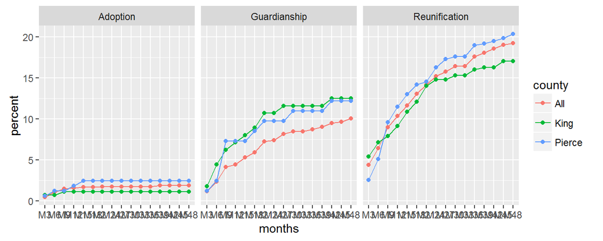

```r
library(ggplot2)
ggplot(reentry, aes(x = months, y = percent, color = county)) +
    geom_line(aes(group = county)) +
    geom_point() +
    facet_wrap(~ outcome)
```

## Data manipulation with `dplyr`

## verbs

`dplyr` has many simple commands, *verbs*, that try to do one thing very well. They all work on data frames.

- `mutate` adds columns
- `arrange` sorts
- `filter` omits rows that don't match condition(s)
- `select` omits columns that aren't selected
- `slice` works like filter, but uses row numbers instead of logical conditions
- `rename` changes column names

## groups

- `group_by` adds a **grouping** to a data frame
  - all subsequent `dplyr` commands will be done to each group individually, as if each group is its own data frame
- `ungroup` removes a grouping
- `summarize` collapses each group to a single row, adding summary columns
  - the only columns kept are the grouping columns and new summary columns

## Non-standard evaluation

All of the `dplyr` verbs use NSE (non-standard evaluation) - unquoted column names.

Hadley is creating a coding style/convention that they all have standard-evaluating counterparts with the same name followed by an underscore.

- `mutate_` is a standard-evaluating version of `mutate`
- `spread_` is a standard-evaluating version of `spread`
- `aes_` is a standard-evaluating version of `aes`

You should use the standard-evaluating versions *inside functions* - when writing general purpose code that might be called by other code, that is expected to operate on different data.

In everyday use, when exploring or analyzing a specific data set, the NSE versions offer nice convenience.

## The Pipe

[figure not shown]

All of these simple verbs are nice for doing simple things one step at a time. What makes `dplyr` really shine is the pipe operator, `%>%`, borrowed from the `magrittr` package.

The pipe does something very simple - it takes the result of whatever is on the left and *pipes* it to the function on the right as the first argument.

## Simple piping

```r
library(dplyr)
1:5 %>% mean
```

```
## [1] 3
```

```r
mtcars %>% head(2)
```

```
##               mpg cyl disp  hp drat    wt  qsec vs am gear carb
## Mazda RX4      21   6  160 110  3.9 2.620 16.46  0  1    4    4
## Mazda RX4 Wag  21   6  160 110  3.9 2.875 17.02  0  1    4    4
```

The above uses are illustrative. These first two example are fairly pointless in practice (`mean(1:5)` is easier to read and understand than `1:5 %>% mean`.

## Lots of pipes

```r
rexp(100) %>%
    log(base = 2) %>%
    sd %>%
    round(2)
```

```
## [1] 1.79
```

This is more approachable than `round(sd(log(rexp(100), base = 2)), 2)`, yet still more concise than doing everything one at-a-time.

## Lots of pipes

Piping is useful when you would normally have lots of *nested* funcitons. Piping lets you write them left-to-right instead of inside-out.

```r
foo = factor(c(4, 8, NA, -1, -1, 2, NA, 10))
# if I want to take the average of the first 5 rows of foo, omitting missing values:
# option 1
bar1 = mean(na.omit(as.numeric(as.character(foo))))

# option 2
bar2 = as.character(foo)
bar2 = as.numeric(bar2)
bar2 = na.omit(bar2)
bar2 = mean(bar2)

# option 3
bar3 = foo %>% as.character %>% as.numeric %>% na.omit %>% mean

identical(bar1, bar2, bar3)
```

```
## [1] TRUE
```

## Piping with `dplyr`

Piping is especially useful chaining `dplyr` verbs together. Every verb expects a data frame as its first argument, and every verb returns a data frame as its outuput, so they go together nicely.

## Some notes…

- Don't let you lines get too long! I almost always start a new line after `%>%`.
  - RStudio's *reformat code* utility can be very helpful: Code > Reformat code.
- `dplyr` is **much** faster than base R functions doing the same tasks
  - However, if you *really* need speed & efficiency, `data.table` is even faster.
  - `dplyr` functions and syntax will work with `data.table` objects to get you partway there.
- There are many `dplyr` commands I did not show you - skimming some of the `dplyr` vignettes would be a good way to dive deeper into this topic.
  - joining operations: `inner_join`, `left_join`, etc., see `?join`
  - helpers `n()`, `distinct`, `desc`
  - `bind_rows` and `bind_cols` are faster versions of `cbind` and `rbind` (and they can take lists are arguments!)
- `do()` can execute *any* function on each of your grouped sub-tables and return a list, so you can
  - make a `ggplot` for each group
  - fit a model to each group
  - write each group to its own CSV
- `summarize_each` and `mutate_each` work on multiple columns at once
- One of the biggest features: `dplyr` can connect to a SQL database on the back-end, *translate dplyr code to SQL code*, and execute it for you.

Sometimes you want to pipe to a function that has a data argument, *but the first argument is not the data argument* :(

The pipe uses some dark magic to let this happen - you can use a dot `.` to mark where the data should go:

```r
mtcars %>%
    filter(cyl == 4) %>%
    lm(mpg ~ wt, data = .) %>%  # dot marks the spot
    coef
```

```
## (Intercept)          wt
##   39.571196   -5.647025
```

## `broom:` tidy models

## Three ways to sweep up

`broom` has 3 main functions that work on a *wide* variety of models and tests.

- `tidy` gives a data frame that summarizes model coefficients
- `augment` adds columns to the data you fit the model on
- `glance` gives a one-row summary of a model, with fit statistics, degrees of freedom, etc.